# Predictive Maintenance using Machine Learning

Using data collectived by TAARIFA, I will explore a possible model that will predict if a waterpoint requires maintenance or in need of repairs (broken).

## Import the data

```r
train<- read.csv(file='Training_Values.csv')
```

```r
test <- read.csv(file='Test_Values.csv')
```

```r
train_labels <- read.csv(file='Training_Labels.csv')
```

```r
train_full <- merge(as.data.frame(train),as.data.frame(train_labels))
```

## Explore raw data

First, I want to take a look at the features and the targets.

```r
head(train_full)
```

| id | amount_tsh | date_recorded | funder | gps_height | installer | longitude | latitude | wpt_name | num_private | ⋯ | water_quality | quality_group | quantity | quantity_group | source | source_type | source_class | waterpoint_type | waterpoint_type_group | status_group |
| --- | --- | --- | --- | --- | --- | --- | --- | --- | --- | --- | --- | --- | --- | --- | --- | --- | --- | --- | --- | --- |
| 0 | 0 | 2012-11-13 | Tasaf | 0 | TASAF | 33.12583 | -5.118154 | Mratibu | 0 | ⋯ | milky | milky | enough | enough | shallow well | shallow well | groundwater | hand pump | hand pump | non functional |
| 1 | 0 | 2011-03-05 | Shipo | 1978 | SHIPO | 34.77072 | -9.395642 | none | 0 | ⋯ | soft | good | enough | enough | shallow well | shallow well | groundwater | hand pump | hand pump | functional |
| 2 | 0 | 2011-03-27 | Lvia | 0 | LVIA | 36.11506 | -6.279268 | Bombani | 0 | ⋯ | soft | good | insufficient | insufficient | machine dbh | borehole | groundwater | communal standpipe multiple | communal standpipe | functional |
| 3 | 10 | 2013-06-03 | Germany Republi | 1639 | CES | 37.14743 | -3.187555 | Area 7 Namba 5 | 0 | ⋯ | soft | good | enough | enough | spring | spring | groundwater | communal standpipe | communal standpipe | functional |
| 4 | 0 | 2011-03-22 | Cmsr | 0 | CMSR | 36.16489 | -6.099289 | Ezeleda | 0 | ⋯ | soft | good | dry | dry | shallow well | shallow well | groundwater | hand pump | hand pump | non functional |
| 5 | 50 | 2011-02-26 | Private | 28 | Private | 39.28612 | -6.972403 | Kwa Namaj | 0 | ⋯ | soft | good | enough | enough | machine dbh | borehole | groundwater | communal standpipe multiple | communal standpipe | functional |

Next, I want to see how the waterpoints are distributed regardless of their status.

```
Using zoom = 6...
```

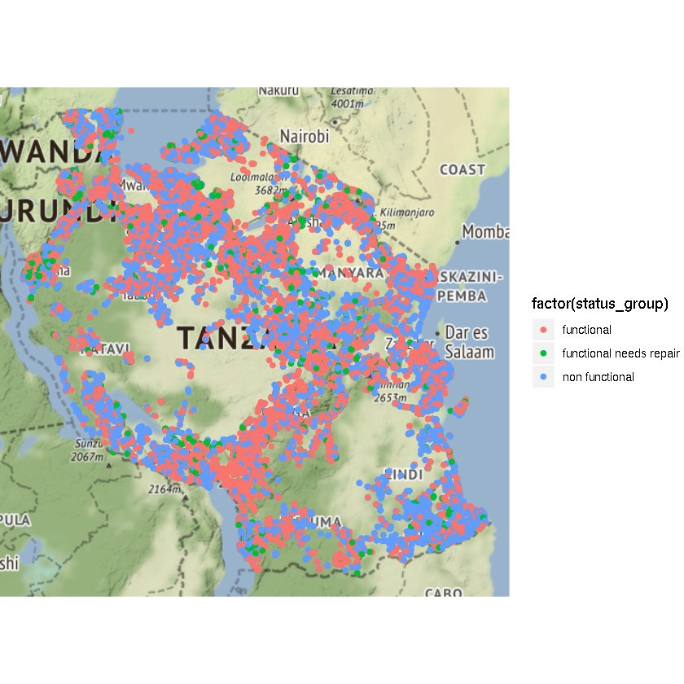

```r
qmplot(longitude,latitude,data=filtered_map, maptype="toner-background", color=factor(status_group))
```

From a quick glance, it doesnt look like there are any obvious concentrations of broken waterpoints. A density map should help highlight the largest concentrations of broken waterpoints.

```
Using zoom = 6...
```

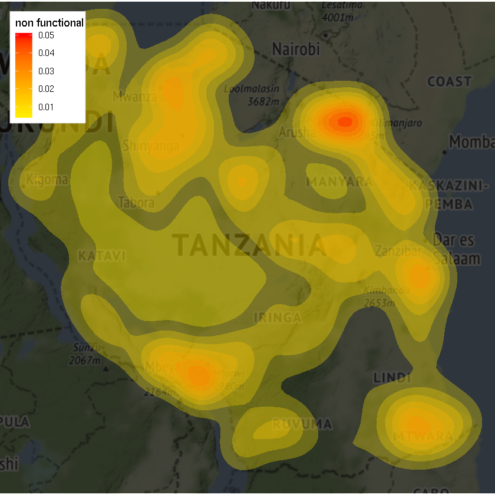

```r
broken_pumps <- filtered_map %>% filter(status_group =="non functional")
qmplot(longitude,latitude,data=broken_pumps, geom = "blank", maptype="toner-background", darken = .7, legend = "topleft")+stat_density_2d(aes(fill=..level..), geom="polygon", alpha=.3, color = NA) + scale_fill_gradient2("non functional", low="white", mid="yellow", high="red")
```

# Looking at the Features

With an idea of what the data looks like, I need to standardize it so it can be used for further analysis.

### Standardize the data

```r
train_full <- train_full %>% mutate_all(na_if,"")
```

```r
test_full <- test %>% mutate_all(na_if,"")
```

```r
train_full <- sapply(train_full,tolower)
```

```r
test_full <- sapply(test_full,tolower)
```

```r
trainDF <- as.data.frame(train_full)
```

```r
testDF <- as.data.frame(test_full)
```

```r
trainDF <- as.data.frame(gsub("[[:punct:]]","",as.matrix(trainDF)))
```

```r
testDF <- as.data.frame(gsub("[[:punct:]]","",as.matrix(testDF)))
```

### Encoding the features

Next, I need to encode the categorical features.

```r
encode_columns <- names(trainDF[,setdiff(colnames(trainDF), c("id","funder","installer","amount_tsh","date_recorded","ward","subvillage","lga","scheme_name","recorded_by","source_type","waterpoint_type","wpt_name","gps_height","longitude","latitude","population","construction_year","region_code","district_code","extraction_type","extraction_type_class","quality_group","quantity_group","payment","num_private","status_group"))])
```

```r
train_encoded_DF <- dummy.data.frame(trainDF, names=as.list(encode_columns),sep="_")
```

```r
test_encoded_DF <- dummy.data.frame(testDF, names=as.list(encode_columns),sep="_")
```

## Checking the target classes

```r
prop.table(table(trainDF['status_group']))
```

```
             functional functional needs repair          non functional
             0.54308081              0.07267677              0.38424242
```

# Train-Test-Validation Split

Next, I split the data into train and validate so I can create a model, tune it, then validate its performance.

```r
n_train <- round(nrow(train_encoded_DF)*.7)
```

```r
TRAIN_DF <- train_encoded_DF
TEST_DF <- test_encoded_DF
```

```r
TRAIN_DF['status_group'] <- TRAIN_DF$status_group%>%factor()%>%as.numeric()
```

```r
n_train <- sample(nrow(TRAIN_DF), .8*nrow(TRAIN_DF),replace=FALSE)
n_valid <- sample(nrow(TRAIN_DF), .2*nrow(TRAIN_DF),replace=FALSE)
train_data <- TRAIN_DF[n_train,]
valid_data <- TRAIN_DF[n_valid,]
train_labels <- as.numeric(train_data$status_group)-1
valid_labels <- as.numeric(valid_data$status_group)-1
```

# Creating a Predictive Model

I chose to use a method called gradient boosted trees since it performs well at combating class imbalance. This technique works by creating an *ensemble* of decision trees (considered weak learners). The ensemble is created iteratively, where each predictor added to the ensemble learns from the *residual errors* of the previous predictor. The final prediction is simply the sum of all predictions. The implementation I chose to use is the popular XGBOOST.

```r
train_xgb <- xgb.DMatrix(data = data.matrix(train_data[1:144]), label = (train_labels))
valid_xgb <- xgb.DMatrix(data = data.matrix(valid_data[1:144]), label= (valid_labels))
```

```r
n_Classes <- length(unique(TRAIN_DF$status_group))
```

```r
xgb_params <- list("objective" = "multi:softprob", "eval_metric"="mlogloss","num_class" = n_Classes)
nround <- 50
cv.nfold <- 5
cv_model <- xgb.cv(params = xgb_params, data = train_xgb, nrounds = nround, nfold = cv.nfold, verbose = FALSE, prediction = TRUE)
```

```r
OOF_predictions <- data.frame(cv_model$pred) %>% mutate(max= max.col(.,ties.method="last"),label = train_labels+1)
```

```r
confusionMatrix(factor(OOF_predictions$max),factor(OOF_predictions$label),mode="everything")
```

```
Confusion Matrix and Statistics

          Reference
Prediction     1     2     3
         1 23693  2162  5032
         2   264   705   129
         3  1949   539 13047

Overall Statistics

               Accuracy : 0.788
                 95% CI : (0.7843, 0.7917)
    No Information Rate : 0.5452
    P-Value [Acc > NIR] : < 2.2e-16

                  Kappa : 0.5913
 Mcnemar's Test P-Value : < 2.2e-16

Statistics by Class:

                     Class: 1 Class: 2 Class: 3
Sensitivity            0.9146  0.20699   0.7166
Specificity            0.6672  0.99109   0.9151
Pos Pred Value         0.7671  0.64208   0.8398
Neg Pred Value         0.8670  0.94182   0.8386
Precision              0.7671  0.64208   0.8398
Recall                 0.9146  0.20699   0.7166
F1                     0.8344  0.31306   0.7733
Prevalence             0.5452  0.07168   0.3832
Detection Rate         0.4986  0.01484   0.2746
Detection Prevalence   0.6500  0.02311   0.3269
Balanced Accuracy      0.7909  0.59904   0.8158
```

The results of cross validation gives a measure of performance: precision, recall, and F-measure.

**Precision** gives an idea of the model's accuracy. It is the ratio of correct predictions over total number of predictions. We can see that the under-represented class has poor accuracy compared to the other classes.

**Recall** is the rate of positive instances detected by the classifier.

**F-measure** is a composite score that combines both precision and recall.

Now, I will train the model using the parameters from cross validation

```r
xgb_model <- xgb.train(params = xgb_params, data = train_xgb, nrounds=100)
```

```r
xgb_val_pred<- predict(xgb_model, newdata = valid_xgb)
```

```r
xgb_val_predictions <- matrix(xgb_val_pred, nrow=n_Classes, ncol=length(xgb_val_pred)/n_Classes)%>%t()%>%data.frame()%>%mutate(label = valid_labels +1, max_prob = max.col(.,"last"))
```

```r
confusionMatrix(factor(xgb_val_predictions$max_prob),factor(xgb_val_predictions$label),mode="everything")
```

```
Confusion Matrix and Statistics

          Reference
Prediction    1    2    3
         1 6105  454  875
         2   41  324   28
         3  300  101 3652

Overall Statistics

               Accuracy : 0.8486
                 95% CI : (0.842, 0.855)
    No Information Rate : 0.5426
    P-Value [Acc > NIR] : < 2.2e-16

                  Kappa : 0.7128
 Mcnemar's Test P-Value : < 2.2e-16

Statistics by Class:

                     Class: 1 Class: 2 Class: 3
Sensitivity            0.9471  0.36860   0.8018
Specificity            0.7554  0.99373   0.9453
Pos Pred Value         0.8212  0.82443   0.9011
Neg Pred Value         0.9233  0.95168   0.8846
Precision              0.8212  0.82443   0.9011
Recall                 0.9471  0.36860   0.8018
F1                     0.8797  0.50943   0.8485
Prevalence             0.5426  0.07399   0.3834
Detection Rate         0.5139  0.02727   0.3074
Detection Prevalence   0.6258  0.03308   0.3412
Balanced Accuracy      0.8513  0.68116   0.8735
```

# Accounting for rare cases

I know that there is an imbalance in the target class, so I will use a technique called SMOTE (Synthetic Minority Over Sampling Technique) to intentionally oversample the minority class so the classifer can make better predictions.

```r
train_data$status_group <- as.factor(train_data$status_group)
```

```r
valid_data$status_group <- as.factor(valid_data$status_group)
```

```r
train_data <- SMOTE(status_group ~ ., train_data, perc.over = 100, perc.under=200)
```

```r
valid_data <- SMOTE(status_group ~ ., valid_data, perc.over = 100, perc.under=200)
```

```r
prop.table(table(train_data['status_group']))
```

```
        1         2         3
0.2944069 0.5000000 0.2055931
```

```r
train_labels <- as.numeric(train_data$status_group)-1
valid_labels <- as.numeric(valid_data$status_group)-1
```

```r
train_xgb <- xgb.DMatrix(data = data.matrix(train_data[1:144]), label = (train_labels))
valid_xgb <- xgb.DMatrix(data = data.matrix(valid_data[1:144]), label= (valid_labels))
```

```r
xgb_params <- list("objective" = "multi:softprob", "eval_metric"="mlogloss","num_class" = n_Classes)
nround <- 50
cv.nfold <- 5
cv_model <- xgb.cv(params = xgb_params, data = train_xgb, nrounds = nround, nfold = cv.nfold, verbose = FALSE, prediction = TRUE)
```

```r
OOF_predictions <- data.frame(cv_model$pred) %>% mutate(max= max.col(.,ties.method="last"),label = train_labels+1)
```

```r
confusionMatrix(factor(OOF_predictions$max),factor(OOF_predictions$label),mode="everything")
```

```
Confusion Matrix and Statistics

          Reference
Prediction    1    2    3
         1 2973  714  578
         2  768 5893  380
         3  270  205 1843

Overall Statistics

               Accuracy : 0.786
                 95% CI : (0.7791, 0.7929)
    No Information Rate : 0.5
    P-Value [Acc > NIR] : < 2.2e-16

                  Kappa : 0.6518
 Mcnemar's Test P-Value : < 2.2e-16

Statistics by Class:

                     Class: 1 Class: 2 Class: 3
Sensitivity            0.7412   0.8651   0.6580
Specificity            0.8656   0.8315   0.9561
Pos Pred Value         0.6971   0.8370   0.7951
Neg Pred Value         0.8891   0.8604   0.9153
Precision              0.6971   0.8370   0.7951
Recall                 0.7412   0.8651   0.6580
F1                     0.7185   0.8508   0.7201
Prevalence             0.2944   0.5000   0.2056
Detection Rate         0.2182   0.4325   0.1353
Detection Prevalence   0.3131   0.5168   0.1701
Balanced Accuracy      0.8034   0.8483   0.8070
```

```r
xgb_model <- xgb.train(params = xgb_params, data = train_xgb, nrounds=100)
```

```r
xgb_val_pred<- predict(xgb_model, newdata = valid_xgb)
```

```r
xgb_val_predictions <- matrix(xgb_val_pred, nrow=n_Classes, ncol=length(xgb_val_pred)/n_Classes)%>%t()%>%data.frame()%>%mutate(label = valid_labels +1, max_prob = max.col(.,"last"))
```

```r
confusionMatrix(factor(xgb_val_predictions$max_prob),factor(xgb_val_predictions$label),mode="everything")
```

```
Confusion Matrix and Statistics

          Reference
Prediction    1    2    3
         1  761   68  139
         2  180 1665   98
         3   72   25  508

Overall Statistics

               Accuracy : 0.8345
                 95% CI : (0.8218, 0.8466)
    No Information Rate : 0.5
    P-Value [Acc > NIR] : < 2.2e-16

                  Kappa : 0.7277
 Mcnemar's Test P-Value : < 2.2e-16

Statistics by Class:

                     Class: 1 Class: 2 Class: 3
Sensitivity            0.7512   0.9471   0.6819
Specificity            0.9173   0.8419   0.9650
Pos Pred Value         0.7862   0.8569   0.8397
Neg Pred Value         0.9011   0.9409   0.9186
Precision              0.7862   0.8569   0.8397
Recall                 0.7512   0.9471   0.6819
F1                     0.7683   0.8998   0.7526
Prevalence             0.2881   0.5000   0.2119
Detection Rate         0.2164   0.4735   0.1445
Detection Prevalence   0.2753   0.5526   0.1721
Balanced Accuracy      0.8343   0.8945   0.8234
```